# Machine Learning Project

Theodore Littleton

February 14, 2016

Link to Github project: https://github.com/Violet-Knight/Machine-Learning-Project  
Link to HTML page: https://rawgit.com/Violet-Knight/Machine-Learning-Project/master/Machine_Learning_Project.html

Project goal: Attempt to predict the manner in which the Human Activity Recognition project was carried out.

I will load the data (already split into training and test sets), clean it, identify what are likely to be relevant variables, train a model, then use it to predict the ‘classe’ categorical variable for each sample in the test set.

First, I load the data and set a specific seed:

```r
library(caret)
pmlTrain <- read.csv("pml-training.csv")
pmlTest <- read.csv("pml-testing.csv")
set.seed(1587)
```

Turning to data clean-up, the dataset begins with 133 columns, most of which are unnecessary and will slow computation. In particular, I am uninterested in data that simply summarize other data, many of whose columns are filled with NA entries anyway. Thus I eliminate columns that express the total, kurtosis, average, max, min, etc. I also eliminate the first seven columns, which contain data which appear to be identifiers or time-dependent, many of which will be spuriously correlated with the exercise type. I do not want the model determining that an exercise was done a particular way only because it was done, for example, by Carlitos.

```r
## Exclude garbage columns (anything summarizing other columns), and first seven,
## which appear to just be identifiers

garbage <- grep('^(total|kurtosis|skewness|max|min|amplitude|var|stddev|avg)', names(pmlTrain))
pmlTrain <- pmlTrain[,-c(1:7, garbage)]
pmlTest <- pmlTest[,-c(1:7, garbage)]
```

I train the model using a random forest algorithm, with five k-folds in order to cross-validate.

```r
trainSample <- createDataPartition(y=pmlTrain$classe, p=0.7, list=FALSE)
pmlTrainSub <- pmlTrain[trainSample,]
pmlTrainValid <- pmlTrain[-trainSample,]

trControl <- trainControl(method = "repeatedcv",
                           number = 5,
                           repeats = 5)

modFit <- train(classe ~ ., method="rf", data=pmlTrainSub, prox=TRUE, trControl=trControl)
```

```r
predictions <- predict(modFit, pmlTrainValid)
confusionMatrix(predictions, pmlTrainValid$classe)
```

```
## Confusion Matrix and Statistics
##
##           Reference
## Prediction    A    B    C    D    E
##          A 1671    8    0    0    0
##          B    2 1128    2    2    1
##          C    0    2 1020   12    3
##          D    0    1    4  949    4
##          E    1    0    0    1 1074
##
## Overall Statistics
##
##                Accuracy : 0.9927
##                  95% CI : (0.9902, 0.9947)
##     No Information Rate : 0.2845
##     P-Value [Acc > NIR] : < 2.2e-16
##
##                   Kappa : 0.9908
##  Mcnemar's Test P-Value : NA
##
## Statistics by Class:
##
##                      Class: A Class: B Class: C Class: D Class: E
## Sensitivity            0.9982   0.9903   0.9942   0.9844   0.9926
## Specificity            0.9981   0.9985   0.9965   0.9982   0.9996
## Pos Pred Value         0.9952   0.9938   0.9836   0.9906   0.9981
## Neg Pred Value         0.9993   0.9977   0.9988   0.9970   0.9983
## Prevalence             0.2845   0.1935   0.1743   0.1638   0.1839
## Detection Rate         0.2839   0.1917   0.1733   0.1613   0.1825
## Detection Prevalence   0.2853   0.1929   0.1762   0.1628   0.1828
## Balanced Accuracy      0.9982   0.9944   0.9953   0.9913   0.9961
```

It appears the the most important variable by a significant margin was the roll of the belt sensor.

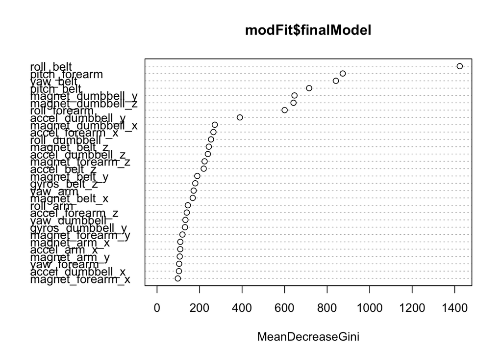

```r
varImpPlot(modFit$finalModel)
```

And to generate the predicted categories for the test variables, simply run the prediction function on the test set using the fitted model.

```r
answers <- predict(modFit, pmlTest)

## answers
```